# IE 582 Statistical Learning for Data Mining - HW2

## Task3

```
Average Decision Tree Accuracy (over 5 folds): 0.6305

Classification Report for Fold 1:
              precision    recall  f1-score   support

    Home win       0.67      0.76      0.71      3131
        Draw       0.57      0.38      0.46      2147
    Away win       0.62      0.69      0.65      2167

    accuracy                           0.63      7445
   macro avg       0.62      0.61      0.61      7445
weighted avg       0.62      0.63      0.62      7445


Classification Report for Fold 2:
              precision    recall  f1-score   support

    Home win       0.67      0.75      0.71      3131
        Draw       0.58      0.38      0.46      2206
    Away win       0.59      0.70      0.64      2108

    accuracy                           0.63      7445
   macro avg       0.62      0.61      0.60      7445
weighted avg       0.62      0.63      0.62      7445


Classification Report for Fold 3:
              precision    recall  f1-score   support

    Home win       0.68      0.72      0.70      3144
        Draw       0.53      0.44      0.48      2150
    Away win       0.63      0.68      0.65      2151

    accuracy                           0.63      7445
   macro avg       0.61      0.61      0.61      7445
weighted avg       0.62      0.63      0.62      7445


Classification Report for Fold 4:
              precision    recall  f1-score   support

    Home win       0.67      0.77      0.72      3160
        Draw       0.58      0.38      0.46      2099
    Away win       0.63      0.69      0.66      2185

    accuracy                           0.64      7444
   macro avg       0.63      0.62      0.61      7444
weighted avg       0.63      0.64      0.63      7444


Classification Report for Fold 5:
              precision    recall  f1-score   support

    Home win       0.64      0.79      0.71      3136
        Draw       0.55      0.43      0.48      2168
    Away win       0.67      0.59      0.63      2140

    accuracy                           0.63      7444
   macro avg       0.62      0.60      0.60      7444
weighted avg       0.62      0.63      0.62      7444
```

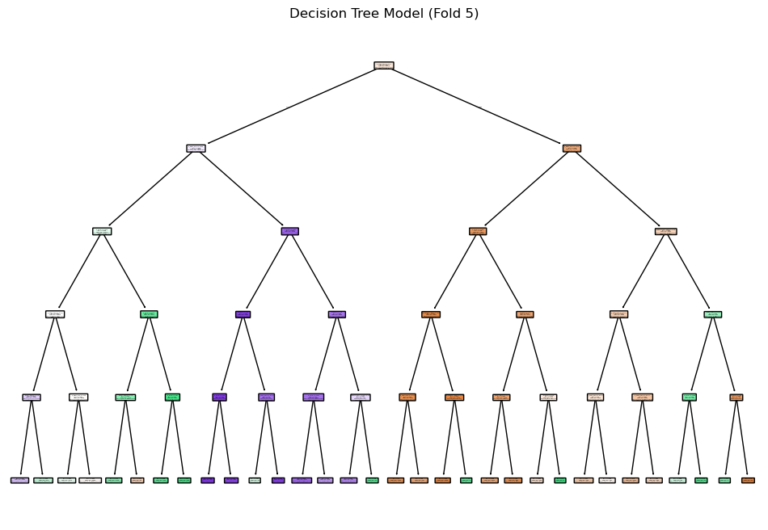

```python
from sklearn.model_selection import KFold
from sklearn.tree import DecisionTreeClassifier, plot_tree
from sklearn.metrics import accuracy_score, classification_report


# Select relevant features for the model (adjust based on the available features)
features = ['Goals - home', 'Goals - away', 'Redcards - home', 'Redcards - away',
            'Yellowcards - home', 'Yellowcards - away', 'Substitutions - home',
            'Substitutions - away', 'minute', 'P_home_win', 'P_draw', 'P_away_win']  # Adjust as needed

# Define your target variable (the result of the match)
target = 'result'

# Prepare the data (filter to ensure no missing values)
X = filtered_data[features]
y = filtered_data[target]

# Convert categorical target values to numeric (if necessary)
y = y.map({'1': 0, 'X': 1, '2': 2})  # 0: Home win, 1: Draw, 2: Away win

# Initialize KFold with shuffling
kf = KFold(n_splits=5, shuffle=True, random_state=42)

# Store the accuracy and other metrics for each fold
accuracies = []
classification_reports = []

# Perform K-fold cross-validation
for train_index, test_index in kf.split(X):
    # Split the data into training and testing sets based on the indices
    X_train, X_test = X.iloc[train_index], X.iloc[test_index]
    y_train, y_test = y.iloc[train_index], y.iloc[test_index]

    # Initialize and fit the Decision Tree Classifier
    tree_model = DecisionTreeClassifier(max_depth=5, min_samples_split=10, random_state=42)
    tree_model.fit(X_train, y_train)

    # Predict the target variable for the test set
    y_pred = tree_model.predict(X_test)

    # Calculate accuracy and other performance metrics
    accuracy = accuracy_score(y_test, y_pred)
    accuracies.append(accuracy)

    # Store the classification report
    classification_reports.append(classification_report(y_test, y_pred, target_names=['Home win', 'Draw', 'Away win']))

# Calculate the average accuracy and display it
average_accuracy = np.mean(accuracies)
print(f"Average Decision Tree Accuracy (over 5 folds): {average_accuracy:.4f}")

# Display classification reports for each fold
for i, report in enumerate(classification_reports):
    print(f"\nClassification Report for Fold {i+1}:\n{report}")

# Visualize the decision tree for the last fold (or any fold of interest)
plt.figure(figsize=(12, 8))
plot_tree(tree_model, filled=True, feature_names=features, class_names=['Home win', 'Draw', 'Away win'], rounded=True)
plt.title(f"Decision Tree Model (Fold {i+1})")
plt.show()
```

[output not shown]

```
       fixture_id  Home Win Difference  Draw Probability Difference  \
0      19172016.0             0.067438                    -0.022425
1      19172016.0             0.081099                    -0.009605
2      19172016.0             0.081099                    -0.009605
3      19172016.0             0.081099                    -0.009605
8      19172016.0             0.081099                    -0.009605
...           ...                  ...                          ...
63934  19135376.0             0.109835                     0.005547
63935  19135376.0             0.124959                     0.005547
63936  19135376.0             0.148667                    -0.022425
63937  19135376.0            -0.040534                     0.107534
63938  19135376.0            -0.014079                     0.065109

       Away Win Probability Difference
0                             0.028505
1                             0.005428
2                             0.005428
3                             0.005428
8                            -0.004828
...                                ...
63934                        -0.051887
63935                        -0.056569
63936                        -0.059149
63937                         0.000197
63938                        -0.003756

[37223 rows x 4 columns]
```

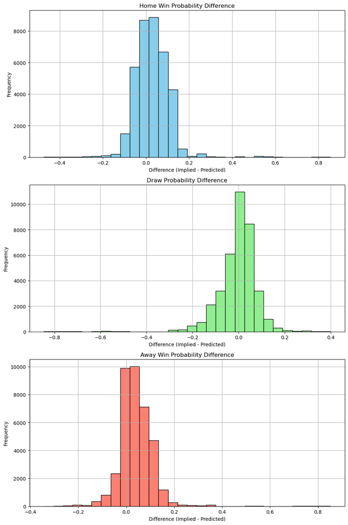

```python
import matplotlib.pyplot as plt
import pandas as pd

# Ensure the model predictions are available, and the implied probabilities are calculated
filtered_data['P_home_win_implied'] = 1 / filtered_data['1']
filtered_data['P_draw_implied'] = 1 / filtered_data['X']
filtered_data['P_away_win_implied'] = 1 / filtered_data['2']

# Use the decision tree model to get predicted probabilities
predicted_probs = tree_model.predict_proba(X)  # Replace X with your feature set

# Store the predicted probabilities for each class (home win, draw, away win)
filtered_data['P_home_win_pred'] = predicted_probs[:, 0]
filtered_data['P_draw_pred'] = predicted_probs[:, 1]
filtered_data['P_away_win_pred'] = predicted_probs[:, 2]

# Calculate the differences
filtered_data['Home Win Difference'] = filtered_data['P_home_win_implied'] - filtered_data['P_home_win_pred']
filtered_data['Draw Probability Difference'] = filtered_data['P_draw_implied'] - filtered_data['P_draw_pred']
filtered_data['Away Win Probability Difference'] = filtered_data['P_away_win_implied'] - filtered_data['P_away_win_pred']

# Print out the calculated differences
print(filtered_data[['fixture_id', 'Home Win Difference', 'Draw Probability Difference', 'Away Win Probability Difference']])

# Plotting the differences
fig, axs = plt.subplots(3, 1, figsize=(10, 15))

# Plot Home Win Difference
axs[0].hist(filtered_data['Home Win Difference'], bins=30, color='skyblue', edgecolor='black')
axs[0].set_title("Home Win Probability Difference")
axs[0].set_xlabel("Difference (Implied - Predicted)")
axs[0].set_ylabel("Frequency")
axs[0].grid(True)

# Plot Draw Probability Difference
axs[1].hist(filtered_data['Draw Probability Difference'], bins=30, color='lightgreen', edgecolor='black')
axs[1].set_title("Draw Probability Difference")
axs[1].set_xlabel("Difference (Implied - Predicted)")
axs[1].set_ylabel("Frequency")
axs[1].grid(True)

# Plot Away Win Probability Difference
axs[2].hist(filtered_data['Away Win Probability Difference'], bins=30, color='salmon', edgecolor='black')
axs[2].set_title("Away Win Probability Difference")
axs[2].set_xlabel("Difference (Implied - Predicted)")
axs[2].set_ylabel("Frequency")
axs[2].grid(True)

# Show the plots
plt.tight_layout()
plt.show()
```

## Conclusion

In this homework, I began by preprocessing the dataset, removing noisy matches influenced by factors like late goals, early red cards, and frequent early substitutions. This ensured that the remaining data was reliable for analysis. I then calculated and normalized the implied probabilities for home wins, draws, and away wins based on bookmaker odds. By analyzing the relationship between these probabilities and match outcomes, I created visualizations to reveal patterns, including the empirical probability of a draw for different ranges of home and away win probabilities. This process highlighted the importance of preprocessing and statistical methods in drawing meaningful insights from sports data.